# Applied Statistics – Exercise 3

## 3. (T)

A fair die is thrown until the sum of the results of the throws exceeds 6. Let the random variable $X$ be the number of throws needed for this. Find the probability mass function of $X$.

## 4. (R)

Consider you have two fair coins that you toss simultaneously (fair coins have a 0.5 probability of heads). You repeat the trial 15 times. Let $X$ be the random variable indicating the number of cases, where both coins come with heads up. In the following exercises you can use the `dbinom` and `pbinom` functions.

1. What is the probability $P(X=5)$?
2. What is the probability $P(X\leq 5)$?

```r
# probability of getting exactly five times {H,H} in 15 double coin tosses
dbinom(5, size=15, prob=.25)
```

```
## [1] 0.165146
```

```r
# probability of getting at most five times (H,H) in 15 double coin tosses
pbinom(5, size=15, prob=.25) # why does this not give the same result?: sum(dbinom(c(1:5), size=15, prob=.25))
```

```
## [1] 0.8516319
```

## 5. (R)

Imagine a football betting setting where there are 13 football games. Each game can have three possible outcomes: home team wins (1), the teams play even (E) or the visitor team wins (2). Model the outcome of each game as a random process where each of the three outcomes are equally probable and independent from other games. Let the random variable $X$ characterise the number of correct guesses for the 13 outcomes in one betting.

1. Write down the analytic forms for the probability mass function of $X$.
2. Illustrate the probability mass function by plotting it in a figure.
3. What is the probability that one gets all the 13 outcomes right?

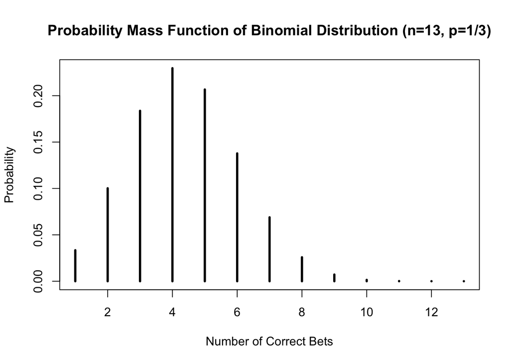

```r
range <- 1:13
pmf <- dbinom(range, size=13, prob=1/3) # a vector holding the probabilities of the number of correct guesses for all possible values of X
plot(range, pmf, main='Probability Mass Function of Binomial Distribution (n=13, p=1/3)', xlab='Number of Correct Bets', ylab='Probability', type='h', lwd=3) # type histogram
```

```r
# probability of getting all bets correct is P(X=13)
print(dbinom(13, size=13, prob=1/3)) # or from variable pmf[13]
```

```
## [1] 6.272255e-07
```

## 6. (R)

You are a collector of soccer players cards. There is just one card missing from your collection. Every day you buy one, and with the probability 1/100 it is the one you are missing. Each purchase is independent from the others. Model the number of days it takes to find the missing card by the random variable $X \sim Geo(1/100)$.

1. Plot the distribution function of $X$.

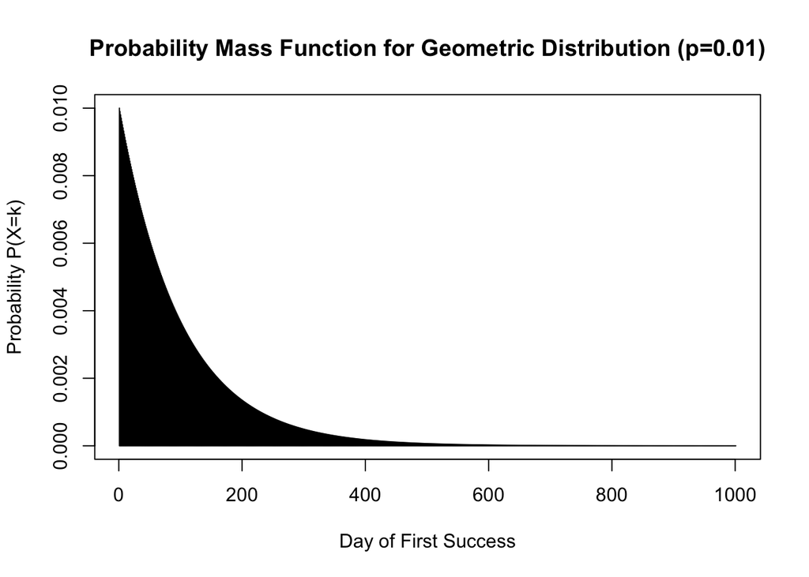

```r
plot(1:1001, dgeom(0:1000, prob=.01), # we need to adjust the ranges because r interprets the k in geometric distributions as the number of failures before first success
     main='Probability Mass Function for Geometric Distribution (p=0.01)',
     xlab="Day of First Success",
     ylab='Probability P(X=k)',
     type='h')
```

[figure not shown]

```r
plot(1:101, pgeom(0:100, prob=.1),
     main = 'Cumulative Probability Function (CMF) for Geometric Distribution (p=.01)',
     xlab = 'Number of Days to reach Probability',
     ylab = 'Probability',
     type='h')
```

2. How many cards do you have to buy so that the chance of finding the missing card is at least $0.5$? How about at least $0.95$? (play with different ranges for $k$).

```r
number.of.cards <- function(k) {
  return (sum(pgeom(0:100, prob=.1) <= k))
}

print(number.of.cards(.5))
```

```
## [1] 6
```

```r
print(number.of.cards(.95))
```

```
## [1] 28
```

3. Assume you have tried for 20 days, but you have not won yet. For how many days do you need to try further so that you have at least a $0.5$ chance of winning?

Since the events, in this case finding the missing player in one of the packs, are independent from one another, it doesn’t matter, for how many days in a row we have not drawn the card. It does not increase our chances of getting him from now on. Therefore the probability of getting the card with a change of at least 50% is equal to our computation for b), so we would have to draw cards for at least 6 more days.